# Goal

# Sample JSON

{ "reviewerID":"A1VEELTKS8NLZB",  
"asin":"616719923X",  
"reviewerName":"Amazon Customer",  
"helpful":[  
0,  
0  
],  
"reviewText":"Just another flavor of Kit Kat but the taste is unique and a bit different. The only thing that is bothersome is the price. I thought it was a bit expensive....",  
"overall":4.0,  
"summary":"Good Taste",  
"unixReviewTime":1370044800,  
"reviewTime":"06 1, 2013"  
}

```python
import spacy

nlp = spacy.load('en')

GOOD_ENTS = ['PERSON', 'NORP', 'FACILITY', 'ORG', 'GPE', 'LOC',
             'PRODUCT', 'EVENT', 'WORK_OF_ART', 'LANGUAGE']

def entities(sent):
    """
    Given a sentence, returns entities, represented at 2-tuples
    with entity text (str) and Spacy entity type label (str)
    """
    #doc = nlp(sent)
    doc=sent
    for ent in doc.ents:
        #  filter out non social entities
        if ent.label_ in GOOD_ENTS:
            return ent.text, ent.label_
        else:
            pass
```

```python
import itertools

def pairs(sent):

    """
    Given a document (list of paras, which is a list of sents,
    which is a list of token,tag tuples), return a list of all
    entity pairs.
    """
    candidates = [
        entities(' '.join(word for word, tag in sent))
        #for para in doc for sent in para
        #for idx, sent in enumerate(doc)
    ]

    doc_entities = [
        entity for entity in candidates if entity is not None
    ]

    return list(itertools.permutations(set(doc_entities), 2))
```

```python
import matplotlib.pyplot as plt
import networkx as nx

from __future__ import unicode_literals, print_function

import plac
import spacy
import sys

title_attributes = set()
reviewerID_ttributes = set()
reviewText_attributes = set()

def appendnode(G,node, attribute):
    #node = row['asin']
    #attribute = row['asin'] #product ID
    if not G.has_node(node):
        G.add_node(node, attribute=attribute)
    return G


def graph(corpus):
    """
    Each document is considered to be unique.  In my case, each review is considered to be unique.

    fileid is equivalent to "asin & reviewerID" and uniquely identifies the review,
    linke reviewerID
    product is asin
    """

    G = nx.Graph(name="Amazon Product Review Graph")
    i=0
    try:

        #title_attributes = set()
        #reviewerID_ttributes = set()
        #reviewText_attributes = set()

        # code here adding nodes




        #node = row['asin']
        #attribute = row['asin'] #product ID
        #if attribute not in myset:
        #    G.add_node(node, attr=attribute)
        #    title_attributes.add(attribute)



        # Create category, feed, and document nodes
        #G.add_nodes_from(corpus.categories(), type='category')
        #G.add_nodes_from([feed['title'] for feed in corpus.feeds()], type='feed')
        #G.add_nodes_from(corpus.fileids(), type='document')
        j=0
        entity=[['PERSON', 'NORP', 'FACILITY', 'ORG', 'GPE', 'LOC',
                 'PRODUCT', 'EVENT', 'WORK_OF_ART', 'LANGUAGE', 'MONEY',
                 'QUANTITY']]

        G=appendnode(G,'PERSON','PERSON')
        G=appendnode(G,'NORP', 'NORP')
        G=appendnode(G,'FACILITY', 'FACILITY')
        G=appendnode(G,'ORG', 'ORG')
        G=appendnode(G,'GPE', 'GPE')
        G=appendnode(G,'LOC', 'LOC')
        G=appendnode(G,'PRODUCT', 'PRODUCT')
        G=appendnode(G,'EVENT', 'EVENT')
        G=appendnode(G,'WORK_OF_ART', 'WORK_OF_ART')
        G=appendnode(G,'LANGUAGE', 'LANGUAGE')
        G=appendnode(G,'MONEY', 'MONEY')
        G=appendnode(G,'QUANTITY', 'QUANTITY')


        for index, row in corpus.iterrows():

            # Product
            node = row['asin']
            attribute = row['asin'] #product ID
            G=appendnode(G,node, attribute)

            # Reviewer
            node = row['reviewerID']
            attribute = row['reviewerID']
            G=appendnode(G,node, attribute)

            # Review
            node = row['reviewText']
            attribute = row['reviewText']
            G=appendnode(G,node, attribute)

            # Create feed-category edges

            # Create
            if not (G.has_edge(row['reviewerID'],row['reviewText']) and
                    G.has_edge(row['asin'],row['reviewText'])):

                G.add_edge(row['reviewerID'], row['reviewText'])
                G.add_edge(row['asin'], row['reviewText'])

            j+=1

            #Extract and assign Entities
            model='en_core_web_sm'
            nlp = spacy.load(model)
            doc = nlp(row['reviewText'] )

            relations = extract_entity_relations(doc)
            print(relations)
            for r1, r2 in relations:
                print('{:<10}\t{}\t{}'.format(r1.text, r2.ent_type_, r2.text))
                if not G.has_edge(row['asin'], r2.ent_type_):
                    G.add_edge(row['asin'], r2.ent_type_)
                else:
                    G.add_edge(row['asin'], r2.ent_type_, weight=1)
        return G


        for index, row in corpus.iterrows():
            print(i)
            i+=1
            if i==1:
                break
            # Create an undirected graph
            #G = nx.Graph(name="Amazon Product Review Graph")

            # Create category, feed, and document nodes
            #G.add_nodes_from(row['asin'], type='product')
            #G.add_nodes_from(row['reviewerID'], type='reviewer')
            #G.add_nodes_from(row['summary'], type='document')

        # Create feed-category edges
        # Create Reviewer-PRODUCT edges
            G.add_edges_from([
                (row['reviewerID'], row['asin'])
            ])

        # Create document-category edges
        # Create document-product edges
            G.add_edges_from([
                (row['summary'], row['title'])
            ])

        # Add edges for each document-entity relationship
        # and between pairs of related entities

#@plac.annotations(
#    model=("Model to load (needs parser and NER)", "positional", None, str))
            model='en_core_web_sm'
            nlp = spacy.load(model)
            doc = nlp(row['reviewText'])
            #for num, sentence in enumerate(parsed_review.sents):
            #for text in TEXTS:
                #doc = nlp(text)
            relations = extract_entity_relations(doc)

            for r1, r2 in relations:
                print('{:<10}\t{}\t{}'.format(r1.text, r2.ent_type_, r2.text))
                G.add_edge(row['summary'], r2.ent_type_)
                G.add_edge(row['reviewerID'], r2.ent_type_)
                G.add_edge(row['reviewerID'], r2.text )

                # Now add edges between entity pairs with a weight
                # of 1 for every document they co-appear in

                if (r1.text, r2.text) in G.edges():
                    G.edges[(r1.text, r2.text)]['weight'] += 1
                else:
                    G.add_edge(r1.text, r2.text, weight=1)

                if (row['reviewText'],r2.ent_type_) in G.edges():
                    G.edges[(row['reviewText'], r2.ent_type_)]['weight'] += 1
                else:
                    G.add_edge(row['reviewText'], r2.ent_type_, weight=1)
    except:
        print("Unexpected error:", sys.exc_info()[0])
        raise

    #return G
```

```python
def extract_entity_relations(doc):
    # merge entities and noun chunks into one token
    spans = list(doc.ents) + list(doc.noun_chunks)
    for span in spans:
        span.merge()

    relations = []
    #GOOD_ENTS = ['PRODUCT']
    GOOD_ENTS = ['PERSON', 'NORP', 'FACILITY', 'ORG', 'GPE', 'LOC',
                 'PRODUCT', 'EVENT', 'WORK_OF_ART', 'LANGUAGE', 'MONEY',
                 'QUANTITY']
    for entity in filter(lambda w: w.ent_type_ in GOOD_ENTS, doc):

        if entity.dep_ in ('attr', 'dobj'):
            subject = [w for w in entity.head.lefts if w.dep_ == 'nsubj']
            if subject:
                subject = subject[0]
                relations.append((subject, entity))
                #relations.append((entity))
        elif entity.dep_ == 'pobj' and entity.head.dep_ == 'prep':
            relations.append((entity.head.head, entity))
            #relations.append((entity))

    return relations
```

```python
G = graph(results)
```

[output not shown]

[output cut: 763 more lines]

[output not shown]

```python
len(G)
```

```
1027
```

```python
#Centrality
import heapq
from operator import itemgetter


def nbest_centrality(G, metric, n=10, attr="centrality", **kwargs):
    # Compute the centrality scores for each vertex
    scores = metric(G, **kwargs)

    # Set the score as a property on each node
    nx.set_node_attributes(G, name=attr, values=scores)

    # Find the top n scores and print them along with their index
    topn = heapq.nlargest(n, scores.items(), key=itemgetter(1))
    for idx, item in enumerate(topn):
        print("{}. {}: {:0.4f}".format(idx + 1, *item))

    return G
```

```python
results.to_pickle(pickledResults)
```

```python
results=pd.read_pickle(pickledResults)
```

```python
type(results)
```

```
pandas.core.frame.DataFrame
```

```python
results.loc['title']
```

[output not shown]

```python
results.loc[1,'title']
```

```
'Japanese Kit Kat Maccha Green Tea Flavor (5 Bag) (4.91oz x 5)'
```

```python
nbest_centrality(G, nx.degree_centrality, 10, "degree")
```

```
1. B0000DID5R: 0.0448
2. ORG: 0.0419
3. B0000DGDMO: 0.0312
4. B0000V8IOE: 0.0263
5. PERSON: 0.0253
6. GPE: 0.0253
7. B0000W0GQQ: 0.0253
8. B0000DJDJZ: 0.0234
9. 616719923X: 0.0195
10. B0000DBN2I: 0.0185
```

```
<networkx.classes.graph.Graph at 0x185bf0358>
```

```python
G.info()
```

[output not shown]

[output not shown]

# Named Entity Recognition

Type Description  
PERSON People, including fictional.  
NORP Nationalities or religious or political groups.  
FACILITY Buildings, airports, highways, bridges, etc.  
ORG Companies, agencies, institutions, etc.  
GPE Countries, cities, states.  
LOC Non-GPE locations, mountain ranges, bodies of water.  
PRODUCT Objects, vehicles, foods, etc. (Not services.)  
EVENT Named hurricanes, battles, wars, sports events, etc.  
WORK_OF_ART Titles of books, songs, etc.  
LAW Named documents made into laws.  
LANGUAGE Any named language.  
DATE Absolute or relative dates or periods.  
TIME Times smaller than a day.  
PERCENT Percentage, including "%".  
MONEY Monetary values, including unit.  
QUANTITY Measurements, as of weight or distance.  
ORDINAL "first", "second", etc.  
CARDINAL Numerals that do not fall under another type.

```python
print("Betweenness centrality")
nbest_centrality(
    G, nx.betweenness_centrality, 10, "betweenness", normalized=True
)
```

```
Betweenness centrality
1. ORG: 0.4899
2. PERSON: 0.1882
3. GPE: 0.1621
4. B0000DID5R: 0.1466
5. B0000DGDMO: 0.1077
6. B0000W0GQQ: 0.0892
7. B0000V8IOE: 0.0807
8. B0000DJDJZ: 0.0740
9. 616719923X: 0.0629
10. MONEY: 0.0607
```

```
<networkx.classes.graph.Graph at 0x185bf0358>
```

```python
from multiprocessing import Pool
import itertools


def partitions(nodes, n):
	"Partitions the nodes into n subsets"
	nodes_iter = iter(nodes)
	while True:
		partition = tuple(itertools.islice(nodes_iter,n))
		if not partition:
			return
		yield partition

# To begin the parallel computation, we initialize a Pool object with the
# number of available processors on our hardware. We then partition the
# network based on the size of the Pool object (the size is equal to the
# number of available processors).
def between_parallel(G, processes = None):
	p = Pool(processes=processes)
	part_generator = 4*len(p._pool)
	node_partitions = list(partitions(G.nodes(), int(len(G)/part_generator)))
	num_partitions = len(node_partitions)

    #Next, we pass each processor a copy of the entire network and
    #compute #the betweenness centrality for each vertex assigned to the
    #processor.

	bet_map = p.map(btwn_pool,
					zip([G]*num_partitions,
						[True]*num_partitions,
						[None]*num_partitions,
						node_partitions))

    #Finally, we collect the betweenness centrality calculations from each
    #pool and aggregate them together to compute the overall betweenness
    #centrality score for each vertex in the network.

	bt_c = bet_map[0]
	for bt in bet_map[1:]:
		for n in bt:
			bt_c[n] += bt[n]
	return bt_c
```

```python
import community

parts = community.best_partition(G)
values = [parts.get(node) for node in G.nodes()]
```

```python
from operator import itemgetter
import networkx as nx
import matplotlib.pyplot as plt


#if __name__ == '__main__':
    # Create a BA model graph
n=1000
m=2

    #G=nx.generators.barabasi_albert_graph(n,m)
    # find node with largest degree
#node_and_degree=G.degree()
#(largest_hub,degree)=sorted(node_and_degree.items(),key=itemgetter(1))[-1]
    # Create ego graph of main hub
#hub_ego = nx.ego_graph(G, "ORG")
#hub_ego=nx.ego_graph(G,largest_hub)
    # Draw graph
#pos=nx.spring_layout(hub_ego)
#nx.draw(hub_ego,pos,node_color='b',node_size=50,with_labels=False)
    # Draw ego as large and red
#nx.draw_networkx_nodes(hub_ego,pos,nodelist=[largest_hub],node_size=300,node_color='r')
#plt.savefig('ego_graph.png')
#plt.show()
```

```python
print(nx.info(G))
```

```
Name: Amazon Product Review Graph
Type: Graph
Number of nodes: 1027
Number of edges: 1148
Average degree:   2.2356
```

```python
spring_pos = nx.spring_layout(G)
```

```python
import matplotlib.pyplot as plt
%matplotlib inline
```

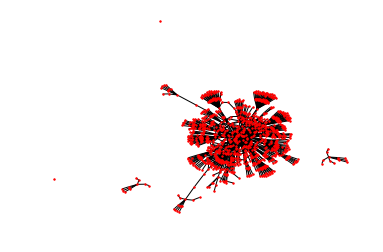

```python
plt.axis("off")
nx.draw_networkx(G, pos = spring_pos,with_labels=False, node_size=2)
```

```python
#plt.savefig('ego_graph.png')
```

```python
plt.show(block=False)
```

```python
plt.savefig("ego_graph.png", format="PNG")
```

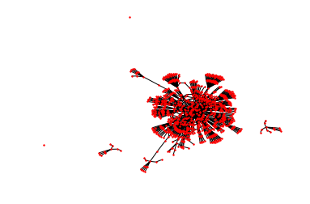

```python
plt.axis("off")
nx.draw_networkx(G, pos = spring_pos,with_labels=False, node_size=2)
```